# lubridate::ceiling_date()

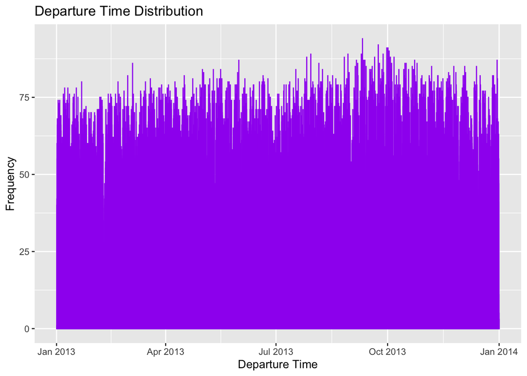

```r
# Plot: Departure time
ggplot(flights_dt, aes(x = dep_time)) +
  geom_histogram(binwidth = 3600, color = "purple", alpha = 0.7) +
  labs(title = "Departure Time Distribution",
       x = "Departure Time",
       y = "Frequency")
```

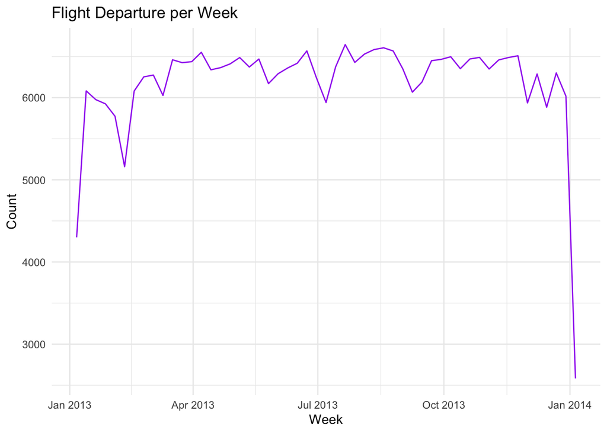

```r
# Plot: Departure for each week
flights_dt %>%
  count(week = ceiling_date(dep_time, "week")) %>%
  ggplot(aes(week, n)) +
    geom_line(color = "purple") +
    theme_minimal() +
    labs(title = "Flight Departure per Week",
         x = "Week",
         y = "Count",
         color = "Line Color")
```

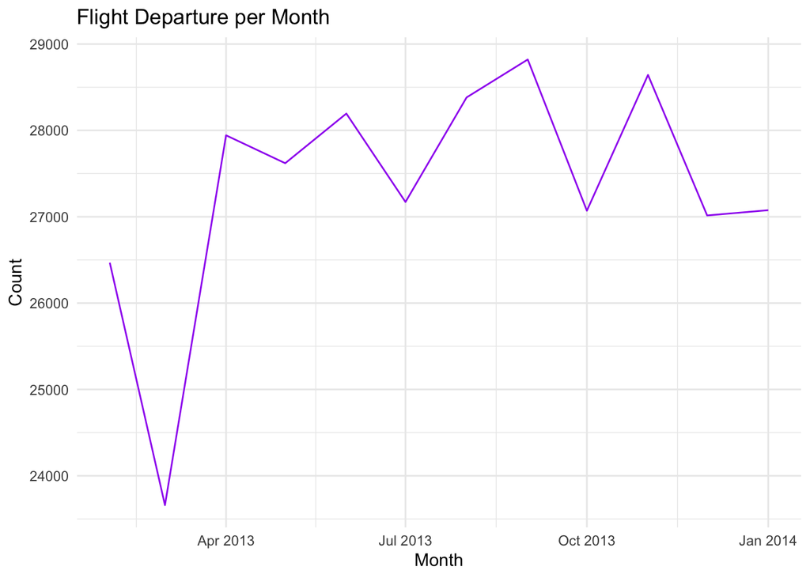

```r
# Plot: Departure for each month
flights_dt %>%
  count(month = ceiling_date(dep_time, "month")) %>%
  ggplot(aes(month, n)) +
    geom_line(color = "purple") +
    theme_minimal() +
    labs(title = "Flight Departure per Month",
         x = "Month",
         y = "Count",
         color = "Line Color")
```

Instead of plotting the original departure time, we can round up to a nearby unit of time using `ceiling_date()`, and allows us to plot the number of flights per week and per month.

Reference:  
1. R for Data Science. https://r4ds.had.co.nz/dates-and-times.html  
2. [How to Write Fuctions in R](https://www.dataquest.io/blog/write-functions-in-r/)

## 1.2 Is it helpful?

Yes, it is useful in representing time in plots and can offer insights into patterns and/or trends over different time intervals. This can be especially true for large datasets where `ceiling_date()` can be used to simplify and group dates to provide a more concise and interpretable representation of trends. I don’t use this everyday, but I do think it is pretty neat!